# White-Britt-ADA-data-reanalysis-assignment

BA White

4/15/2020

# Data reanalysis of: Mahler, D. L., S. M. Lambert, A. J. Geneva, J. Ng, S. B. Hedges, J. B. Losos, and R. E. Glor. 2016. Discovery of a Giant Chameleon-Like Lizard (*Anolis*) on Hispaniola and Its Significance to Understanding Replicated Adaptive Radiations. The American Naturalist 188:357–364.

SUMMARY: Mahler et al. 2016 demonstrates that a newly discovered species of anole is ecomorhpologically similar to unrelated anoles from other islands. GOAL: Is *Anolis landestoyi* close to anoles with similar ecomorphology in morphological space? If yes, to what degree? DATASET: 5Loc_25milburn_100kthin.MCC.median.nex and Traits.csv from http://dx.doi.org/10.5061/dryad.sf540 ANALYSES: Bayesian Phylogenetic Methods, Posterior Probability, and analyses replicated in this text; (1) Phylogenetic Generalized Least Squares Regression [PGLS], (2) Phylogenetic Principal Component Analysis [pPCA], (3) Euclidean Distance Matrix, (4) Linear Discriminant Analysis.

# Ecomorphological Affinities

## Goal: Quantify the ecomorphological similarity of *Anolis landestoyi* to other anoles

### Using pPCA Revell (2009) on a covariance matrix of log-transformed and averaged data for body size and

### shape residuals (from a PGLS) with the Bayesian MCC chronogram they calculated independent “size” and “shape” axes.

### Load necessary packages for data tidying and transformation

```r
library(tidyverse)
library(phytools)
```

### The Dryad “Traits.csv” contains 29 more species than their data table results and 2 species are swapped so a data file has been altered with these changes.

```r
traits_3 <- read_csv("Traits_3.csv", col_names = TRUE)
glimpse(traits_3)
```

```
## Rows: 101
## Columns: 13
## $ species      <chr> "ahli", "alayoni", "alfaroi", "aliniger", "allisoni", ...
## $ AVG_SVL      <dbl> 4.039125, 3.815705, 3.526655, 4.036557, 4.375390, 4.04...
## $ AVG_femur    <dbl> 2.741378, 2.065121, 2.172476, 2.475445, 2.795145, 2.73...
## $ AVG_tibia    <dbl> 2.686032, 2.016402, 2.094946, 2.344015, 2.687734, 2.68...
## $ AVG_met      <dbl> 2.254620, 1.535253, 1.547563, 1.867176, 2.178155, 2.21...
## $ AVG_ltoe_IV  <dbl> 2.553344, 1.875258, 1.732540, 2.256541, 2.533697, 2.49...
## $ AVG_humerus  <dbl> 2.460728, 1.947873, 1.628260, 2.298878, 2.618551, 2.45...
## $ AVG_radius   <dbl> 2.268511, 1.687093, 1.401183, 2.091864, 2.341565, 2.26...
## $ AVG_lfing_IV <dbl> 1.943288, 1.403029, 1.040277, 1.702199, 1.983412, 1.91...
## $ Foot_Lam_num <dbl> 3.279600, 3.432372, 3.198016, 3.582875, 3.721185, 3.33...
## $ Hand_Lam_num <dbl> 2.866197, 3.075269, 2.733866, 3.156774, 3.239211, 2.80...
## $ Avg_lnSVL2   <dbl> 3.939015, 3.743863, 3.478776, 3.933181, 4.355582, 4.02...
## $ Avg_ln_t1    <dbl> 4.406652, 4.002788, 4.369448, 4.441203, 5.039851, 4.51...
```

### Ultimately they excluded ‘AVG_lnSVL2’ from the trait analyses.

```r
traits <- select(traits_3, c(1:11,13))
glimpse(traits)
```

```
## Rows: 101
## Columns: 12
## $ species      <chr> "ahli", "alayoni", "alfaroi", "aliniger", "allisoni", ...
## $ AVG_SVL      <dbl> 4.039125, 3.815705, 3.526655, 4.036557, 4.375390, 4.04...
## $ AVG_femur    <dbl> 2.741378, 2.065121, 2.172476, 2.475445, 2.795145, 2.73...
## $ AVG_tibia    <dbl> 2.686032, 2.016402, 2.094946, 2.344015, 2.687734, 2.68...
## $ AVG_met      <dbl> 2.254620, 1.535253, 1.547563, 1.867176, 2.178155, 2.21...
## $ AVG_ltoe_IV  <dbl> 2.553344, 1.875258, 1.732540, 2.256541, 2.533697, 2.49...
## $ AVG_humerus  <dbl> 2.460728, 1.947873, 1.628260, 2.298878, 2.618551, 2.45...
## $ AVG_radius   <dbl> 2.268511, 1.687093, 1.401183, 2.091864, 2.341565, 2.26...
## $ AVG_lfing_IV <dbl> 1.943288, 1.403029, 1.040277, 1.702199, 1.983412, 1.91...
## $ Foot_Lam_num <dbl> 3.279600, 3.432372, 3.198016, 3.582875, 3.721185, 3.33...
## $ Hand_Lam_num <dbl> 2.866197, 3.075269, 2.733866, 3.156774, 3.239211, 2.80...
## $ Avg_ln_t1    <dbl> 4.406652, 4.002788, 4.369448, 4.441203, 5.039851, 4.51...
```

### Load NEXUS tree file - they specify this specific NEXUS tree in their README file.

```r
tree <- read.nexus("5Loc_25milburn_100kthin.MCC.median.nex")
```

### The number of taxa in the trait data and tree do not match.

```r
tip_label <-tibble(tree$tip.label)

traits4tree <- traits %>%
  semi_join(tip_label, c("species" = "tree$tip.label"))
```

### Trait dataframe must be a MATRIX with species as rownames of that matrix; as required by the pPCA

```r
sp <- traits4tree$species
t <- select(traits4tree,-species)
t <- as.matrix(t)
rownames(t) <- sp
```

### Now prune the branches of the tree for species not found in the morphology dataset

```r
pruned.tree<-drop.tip(tree,tree$tip.label[-match(traits4tree$species, tree$tip.label)])
```

### The trait data provided in the csv have been averaged and log transformed by the original author but the data require size correction before use in the species pPCA. To do this we will conduct a phylogenetic regression of SVL against the other morphological traits (using phytools) then collect the residuals for each trait value.

```r
SVL4pgls <- select(traits4tree, AVG_SVL)
SVL4pgls <- as.matrix(SVL4pgls)
rownames(SVL4pgls) <- sp

traits_as_resids <- phyl.resid(pruned.tree, SVL4pgls, t, method="BM")

output <- traits_as_resids$resid
```

### Now we build a model of phylogenetic relationships to the covariance matrix of trait residuals to determine if covariance occurs at a rate greater than expected by Brownian Motion. The stats for the trait loadings indicate similar loading values for traits to Mahler et al. 2016 except PC2 shows much less loading for ‘AVG_SVL’ and generally their values are positive when mine are negative.

```r
pPCA <- phyl.pca(pruned.tree, output, method="BM", mode="cov")
pPCA
```

```
## Phylogenetic pca
## Standard deviations:
##          PC1          PC2          PC3          PC4          PC5          PC6
## 8.360105e-02 4.265635e-02 3.803501e-02 2.152264e-02 1.730052e-02 1.007667e-02
##          PC7          PC8          PC9         PC10         PC11
## 8.396533e-03 7.517699e-03 5.344190e-03 3.989179e-03 7.372697e-17
## Loads:
##                        PC1         PC2         PC3         PC4         PC5
## AVG_SVL       0.0008711938  0.10977625  0.04704902 -0.10606168 -0.01022630
## AVG_femur    -0.9030083880 -0.17856967 -0.17019987 -0.08895113  0.24533513
## AVG_tibia    -0.9325251442 -0.15623984 -0.12702937 -0.06854062  0.26037017
## AVG_met      -0.9727286846 -0.03199953 -0.08147127  0.05146258  0.14341866
## AVG_ltoe_IV  -0.9246497089 -0.05502736 -0.01126541  0.35329162 -0.08601091
## AVG_humerus  -0.6310295994 -0.53015524 -0.20737953 -0.32001168 -0.27017940
## AVG_radius   -0.6661961945 -0.56087586 -0.29078239 -0.31521762 -0.14188066
## AVG_lfing_IV -0.8220324893 -0.36605525 -0.14914047  0.26871042 -0.25427160
## Foot_Lam_num -0.2691397761 -0.33383294  0.86229087  0.13143397  0.11369263
## Hand_Lam_num -0.0337948771 -0.57631941  0.78276580 -0.14499679 -0.04958924
## Avg_ln_t1    -0.7992725889  0.53904099  0.21778830 -0.12578783 -0.08426142
##                       PC6          PC7         PC8          PC9         PC10
## AVG_SVL      -0.015533280 -0.064778803  0.06570078 -0.160835359 -0.208417656
## AVG_femur    -0.140089074  0.093845183 -0.15833863 -0.031390541  0.033626550
## AVG_tibia    -0.045917906 -0.081364102  0.06180492  0.014458835 -0.067835006
## AVG_met       0.090315162 -0.013958493  0.08317431  0.035384900  0.079989585
## AVG_ltoe_IV   0.031934097 -0.011747845  0.00283070 -0.091604873 -0.009893600
## AVG_humerus   0.028495000 -0.291496253 -0.12369808 -0.010853521  0.033546460
## AVG_radius    0.136153385  0.131974228  0.02578652 -0.016940963 -0.025443045
## AVG_lfing_IV -0.131422380  0.037707827 -0.00363227  0.111245239 -0.009028150
## Foot_Lam_num  0.166465620  0.003528676 -0.10654863  0.052294498 -0.023713483
## Hand_Lam_num -0.141018080  0.007083505  0.09090128 -0.042302191  0.022794663
## Avg_ln_t1    -0.009936039  0.009460403 -0.00331525  0.004444447 -0.004986044
##                       PC11
## AVG_SVL       1.0000000000
## AVG_femur    -0.0377374700
## AVG_tibia     0.0025235478
## AVG_met      -0.0325146587
## AVG_ltoe_IV  -0.0267211480
## AVG_humerus  -0.0267342416
## AVG_radius   -0.0418911955
## AVG_lfing_IV -0.0904672855
## Foot_Lam_num -0.0246973897
## Hand_Lam_num -0.0008247714
## Avg_ln_t1     0.0825752976
```

### My first 4 PC axex also account for 94% of the variation but the variance explained for PC1, PC2, and PC3 differ from Mahler et al. 2016 (supplemental table s11). Species scores are also similar except sign flipped.

```r
summary(pPCA)
```

```
## Importance of components:
##                               PC1        PC2        PC3        PC4        PC5
## Standard deviation     0.08360105 0.04265635 0.03803501 0.02152264 0.01730052
## Proportion of Variance 0.61900469 0.16115282 0.12812612 0.04102623 0.02650872
## Cumulative Proportion  0.61900469 0.78015750 0.90828362 0.94930985 0.97581857
##                                PC6         PC7         PC8         PC9
## Standard deviation     0.010076667 0.008396533 0.007517699 0.005344190
## Proportion of Variance 0.008992995 0.006244110 0.005005418 0.002529498
## Cumulative Proportion  0.984811564 0.991055674 0.996061091 0.998590589
##                               PC10         PC11
## Standard deviation     0.003989179 7.372697e-17
## Proportion of Variance 0.001409411 4.814190e-31
## Cumulative Proportion  1.000000000 1.000000e+00
```

```r
pPCA$S
```

```
##                         PC1           PC2           PC3          PC4
## aliniger         0.25596674 -0.1934425774  0.1462753655  0.022081927
## allisoni         0.20950795  0.0898201286  0.2180694578 -0.061529364
## altitudinalis    0.65260121 -0.1577561961  0.3098952542 -0.143148342
## alutaceus       -0.26181749  0.2912779406  0.1718977443 -0.055233274
## angusticeps      0.63484606  0.0984148589  0.0517610966  0.004655776
## argenteolus     -0.47299470 -0.2909757729  0.2482776994 -0.117899520
## armouri         -0.26260457 -0.1604459637 -0.2941206643  0.095865784
## bahorucoensis   -0.40318438  0.2010837962  0.0413642953  0.059552836
## baleatus         0.01553848  0.0002779947 -0.0085412189 -0.023571572
## barahonae        0.04464138 -0.0181764813 -0.0395992161  0.017611390
## barbouri        -0.24317086  0.3349309587 -0.4767651310 -0.027192406
## bartschi        -0.45839336 -0.2170233942  0.1099702850 -0.116955247
## brevirostris    -0.15772735 -0.3808429000 -0.0984930189 -0.071736035
## terueli          0.21072217  0.0805268036  0.0390223692 -0.069864184
## chamaeleonides   0.67754353 -0.3168070309 -0.1236209295  0.103724869
## chlorocyanus     0.06265096 -0.0171074297  0.3074319988  0.001290084
## christophei     -0.41002723 -0.3182928385 -0.0366860033  0.079533856
## coelestinus      0.01739956  0.0351203684  0.2203939080 -0.029658893
## cooki           -0.34255888  0.0179160057 -0.0358714607 -0.083804934
## cristatellus    -0.24944919 -0.1788724829 -0.1067634817  0.029284238
## cuvieri         -0.30759736 -0.0024795674 -0.0395808792 -0.074688336
## cyanopleurus    -0.41338917  0.3700685686  0.0427897183 -0.020659854
## cybotes         -0.34358645 -0.1010667356 -0.2762003897  0.008656311
## distichus       -0.19314731 -0.4371095759 -0.1691403627 -0.036866258
## dolichocephalus -0.25914407  0.3021492560  0.2557644994  0.045825261
## equestris        0.06939560 -0.0529776371  0.3062383927 -0.090691750
## etheridgei      -0.69612548 -0.0360858015 -0.1172235502  0.109643151
## eugenegrahami   -0.61141826 -0.3452909157  0.0711347198  0.014496601
## evermanni       -0.24646224 -0.3030284781  0.2316103602  0.056396685
## fowleri         -0.36517153  0.2353676064 -0.1657241563 -0.087426544
## garridoi         1.20219744 -0.0906719652  0.0843977066  0.081861236
## grahami         -0.17251221 -0.2110442341  0.1596711681 -0.060047742
## guafe           -0.14287390 -0.3346629452 -0.2316551991  0.012008150
## guamuhaya        0.53263281 -0.2703376379  0.0389800479  0.195721990
## gundlachi       -0.47325850  0.0183041300 -0.4094409085  0.046430371
## hendersoni      -0.35519924  0.2750965988  0.1921924775  0.041602622
## imias           -0.33158963 -0.2038643510 -0.3277358532 -0.065755465
## insolitus        0.71141920 -0.0283773351 -0.1736004560  0.132073811
## jubar           -0.14259277 -0.2283330611 -0.2072365841  0.005691006
```

[output cut: 164 more lines]

```
## reconditus       1.101784e-02  0.0185833997 -9.246483e-16
## ricordii         4.129904e-02 -0.0211276453 -9.246483e-16
## rubribarbus      4.265081e-03  0.0242729759 -3.646984e-17
## sagrei           1.431266e-02  0.0068841002 -3.646984e-17
## semilineatus    -4.381545e-02 -0.0006722911  4.076194e-16
## sheplani         7.048979e-02 -0.0159243891  4.076194e-16
## shrevei          3.395291e-03  0.0440972399 -3.646984e-17
## singularis      -1.707379e-03 -0.0288223082 -3.646984e-17
## smallwoodi       3.215210e-02  0.0026588756 -9.246483e-16
## strahmi         -1.390655e-02  0.0084560490 -3.646984e-17
## stratulus        3.489751e-02 -0.0105190374 -3.646984e-17
## valencienni     -1.395914e-02  0.0006566402 -3.646984e-17
## vanidicus       -2.516147e-02 -0.0304470980  4.076194e-16
## vermiculatus     2.208687e-02 -0.0004691939 -9.246483e-16
## whitemani        5.104376e-03  0.0166165649 -3.646984e-17
```

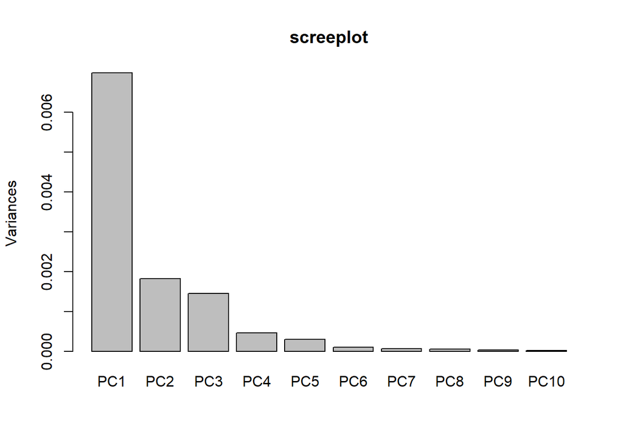

```r
plot(pPCA)
```

### Calculate the Euclidean distance to every other species from *A. landestyoi* by the first four axes of the phylogenetic PCA on trait residuals. My Euclidean distance values are EXTREMELY different from the authors based on the histograms. I did have to do the most guessing of packages/variables used here because it wasn’t stated.

```r
scores <- as_tibble(pPCA$S)
fourscores <- select(scores, c(1:4))
fourscores <- as.matrix(fourscores)
rownames(fourscores) <- sp
distance.matrix <- dist(fourscores, method = "euclidean", diag = T)
distance.matrix <- as.matrix(distance.matrix)
distance.matrix <- as.tibble(distance.matrix)
```

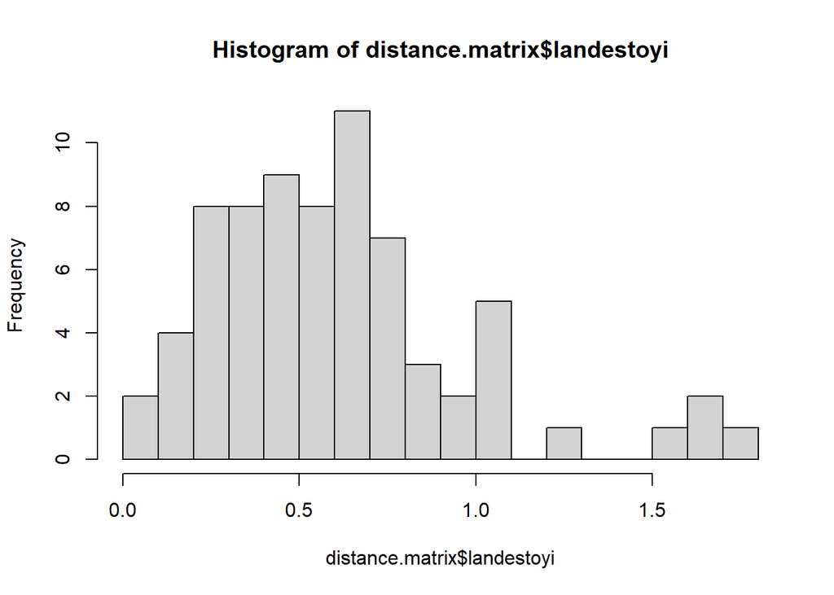

```r
landestoyialone <- select(distance.matrix, c('landestoyi'))
landestoyialone <- as.matrix(landestoyialone)
rownames(landestoyialone) <- sp
hist(distance.matrix$landestoyi, breaks = 16, right = TRUE)
```

### The hist from Mahler et al. 2016 has a mean +0.5 greater than the hist I generated, see here:

```r
mahler <- read_csv("euclideanAll.csv", col_names = TRUE)
```

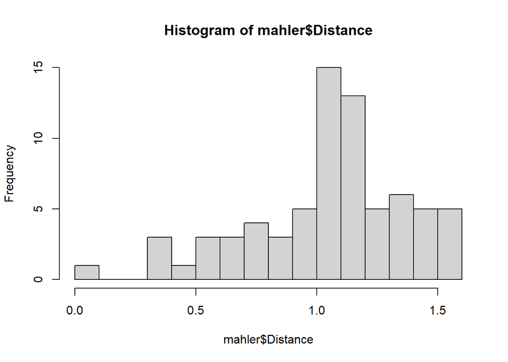

```r
hist(mahler$Distance,breaks = 16, right = TRUE)
```

### Take the ‘mahler’ data to acquire ecomorph type for each species and combine with Euclidean species scores.

```r
### PCA 4 Scores per speices + ecomorphs
ecomo <- select(mahler, c('Species','Ecomorph'))
ecomo1 <- cbind(sp, scores)
ecomo1 <- select(ecomo1, c(1:5))
eco_scores1 <- full_join(ecomo1, ecomo, c('sp' = 'Species'))

### Euclidean distance from landestoyis + ecomorphs
ecosp <- as.tibble(cbind(sp, landestoyialone))
eco_s <- full_join(ecomo, ecosp, c('Species' = 'sp'))
eco_s
```

```
## # A tibble: 72 x 3
##    Species       Ecomorph     landestoyi
##    <chr>         <chr>        <chr>
##  1 aliniger      Trunk-Crown  0.800349258112578
##  2 allisoni      Trunk-Crown  0.806095483194994
##  3 altitudinalis Trunk-Crown  1.21261052878749
##  4 alutaceus     Grass-Bush   0.620108619883931
##  5 angusticeps   Twig         1.06777505323968
##  6 argenteolus   Unique       0.678354913444872
##  7 armouri       Trunk-Ground 0.200729843874881
##  8 bahorucoensis Grass-Bush   0.46386412112653
##  9 baleatus      Crown-Giant  0.499765076539394
## 10 barahonae     Crown-Giant  0.50130396568034
## # ... with 62 more rows
```